# 주제 : 트렌드 분석을 통한 공연 기획

## 소주제 : 공연 장소 트렌드 분석 - 김도영

#### 출처

- 데이터 프레임
  - KOPIS 공연예술 통합전산망
    - https://www.kopis.or.kr/por/main/main.do
- 웹 크롤링
  - 인터파크 티켓 2004~2022년 카테고리별 랭킹 top 50
    - http://ticket.interpark.com/contents/Ranking/RankList?pKind=P&pCate=&pType=Y&pDate=20220727
  - 인터파크 티켓 현재 지역별 예매
    - http://ticket.interpark.com/TiKi/Special/TPRegionReserve.asp?Region=42001&RegionName=%BC%AD%BF%EF

### 계획

- 카테고리별 공연 장소를 워드 클라우드를 통해 가장 많이 나오는 것을 알아보기
- 지역별 공연 장소를 워드 클라우드를 통해 가장 많이 나오는 것을 알아보기
- 조원들과 의견을 조합한 것에 대해 장소 트렌드 분석

```python
# 모듈 로딩
import requests
from bs4 import BeautifulSoup
from konlpy.tag import Okt
from collections import Counter
from wordcloud import WordCloud
import matplotlib.pyplot as plt
import time
import re
import platform
import matplotlib.font_manager as fm
import pandas as pd

if platform.system() == 'Windows':
    font_name = fm.FontProperties(fname='../../EXAM_PANDAS/Fonts/malgun.ttf').get_name()
    plt.rc('font', family=font_name)

else:
    plt.rc('font', family='AppleGothic', size=8)
```

### 공연장 수가 많은 지역 알아보기

```python
df=pd.read_excel('공연시설.xls')

df.columns=['공연시설DB','시설명','공연장수','총객석수','공연장명','객석수','시설특성','개관연도','지역/시(도)','지역/구(군)','주소']
```

```python
df.drop([0,1,2,3],inplace=True)

df
```

```python
region_value=[]
region=[]
for i in df['지역/시(도)'].unique():
    region_value.append(df[df['지역/시(도)']==i].shape[0])
    region.append(i)

region_value=pd.Series(region_value)
region=pd.Series(region)
rg=pd.concat([region, region_value],axis=1)
rg=rg.sort_values(by=1, ascending=False)
```

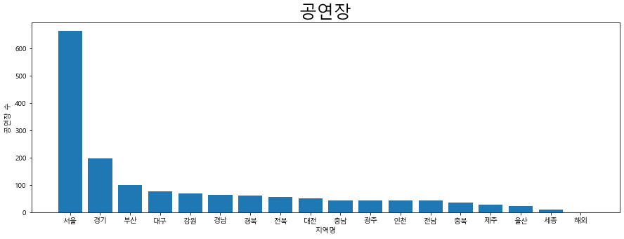

```python
plt.figure(figsize=(15,5))
plt.bar(rg[0],rg[1])
plt.title('공연장',fontsize=25)
plt.xlabel('지역명')
plt.ylabel('공연장 수')
plt.show()
```

- 전국에서 서울, 경기, 부산, 대구 순으로 공연장 수가 많은 것을 알 수 있습니다.

## 인터파크 티켓 2004~2022년 카테고리별 랭킹 top 50 장소

```python
html1=requests.get('http://ticket.interpark.com/contents/Ranking/RankList?pKind=P&pCate=&pType=Y&pDate=20220727')
soup1=BeautifulSoup(html1.text, 'html.parser')

a=[]
for i in soup1.find_all('div',{'class':'rankingContent'})[1:]:
    a.append(i.find_all('li'))

# 분야별 주소 들고오기
url=[]
for i in a[0]:
    url.append(i['data-kind'])

# 연도뽑기
year=soup1.find('div',{'class':'years'})
year_a=year.find_all('a')

years=[]
for i in year_a:
    years.append(i['onclick'].split("'")[1])

name_end=[]
value_end=[]

for j in years:
    value_mid=[]
    for i in url[1:]:
        html=requests.get('http://ticket.interpark.com/contents/Ranking/RankList?pKind='+i+'&pCate=&pType=Y&pDate='+j)
        soup=BeautifulSoup(html.text, 'html.parser')


        # 공연명, 장소 뽑기
        div=soup.find('div',{'class':'rankingDetailBody'})
        value=[]
        for i in div.find_all('a'):
            value.append(i.text)

        values=[]
        for i in value:
            if i!='':
                values.append(i.strip())

        for i in values:
            name_end.append(i.split('\r\n\t')[0])
            value_mid.append(i.split('\r\n\t')[-1].strip())
    value_end.append(value_mid)
```

```python
url
```

```
['P', '01011', '01003', '01009', 'C', 'RK811', 'RK812', '01008', 'F']
```

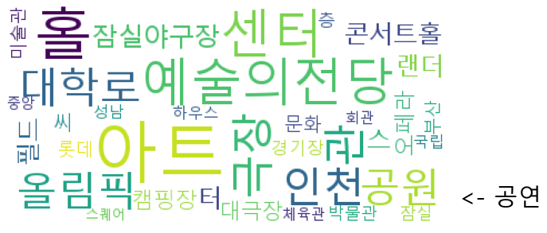

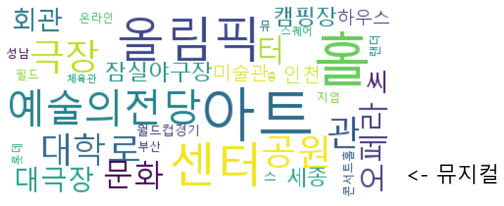

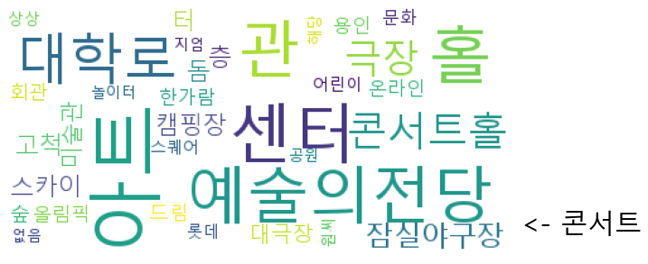

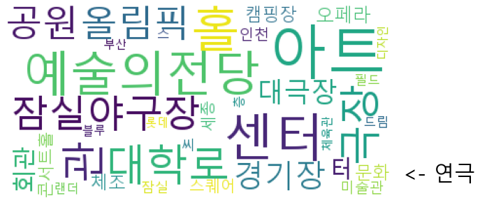

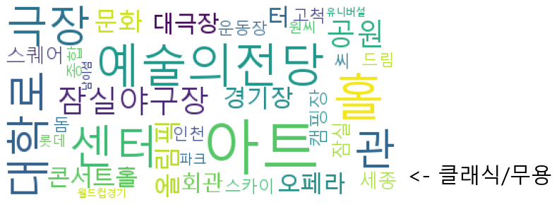

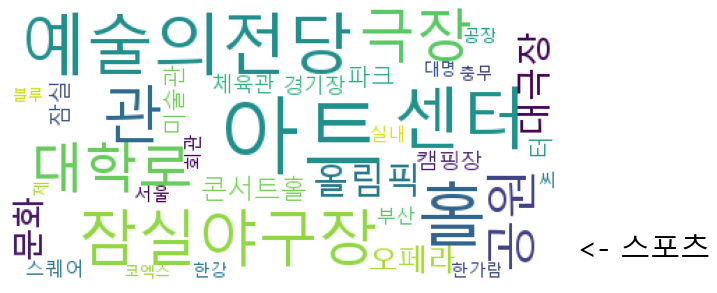

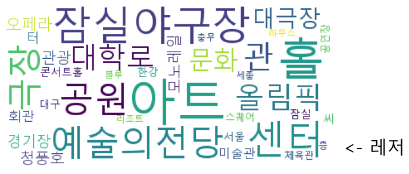

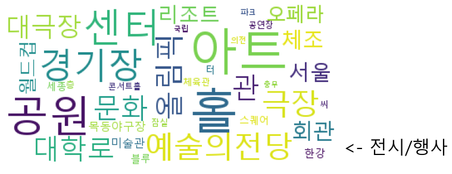

```python
okt = Okt() # Open Korean Text 객체 생성

tagss=[]
# okt함수를 통해 읽어들인 내용의 형태소를 분석한다.
sentences_tag1,sentences_tag2,sentences_tag3,sentences_tag4,sentences_tag5,sentences_tag6,sentences_tag7,sentences_tag8,sentences_tag9 = [],[],[],[],[],[],[],[],[]
sentences_tag1 = okt.pos(str(value_end[0]))
sentences_tag2 = okt.pos(str(value_end[1]))
sentences_tag3 = okt.pos(str(value_end[2]))
sentences_tag4 = okt.pos(str(value_end[3]))
sentences_tag5 = okt.pos(str(value_end[4]))
sentences_tag6 = okt.pos(str(value_end[5]))
sentences_tag7 = okt.pos(str(value_end[6]))
sentences_tag8 = okt.pos(str(value_end[7]))
sentences_tag9 = okt.pos(str(value_end[8]))

noun_adj_list = []
# tag가 명사이거나 형용사인 단어들만 noun_adj_list에 넣어준다.
for word, tag in sentences_tag1:
    if tag in ['Noun' , 'Adjective']:
        noun_adj_list.append(word)

# print(noun_adj_list)
# 가장 많이 나온 단어부터 20개를 저장한다.
counts = Counter(noun_adj_list)
tags = counts.most_common(25)
# print(tags)
tagss.append(tags)
# WordCloud를 생성한다.
# 한글을 분석하기위해 font를 한글로 지정해주어야 된다. macOS는 .otf , window는 .ttf 파일의 위치를
# 지정해준다. (ex. '/Font/GodoM.otf')
if platform.system() == 'Windows':
    path = r'c:\Windows\Fonts\malgun.ttf'
elif platform.system() == 'Darwin': # Mac OS
    path = r'/System/Library/Fonts/AppleGothic'
else:
    path = r'/usr/share/fonts/truetype/name/NanumMyeongjo.ttf'

wc = WordCloud(font_path=path, background_color="white", max_font_size=60)
cloud = wc.generate_from_frequencies(dict(tags))

# 생성된 WordCloud를 test.jpg로 보낸다.
#cloud.to_file('test.jpg')

plt.figure(figsize=(10, 8))
plt.axis('off')
plt.imshow(cloud)
plt.text(x=400, y = 180 ,s=' <- 공연', color = 'black', fontsize = 30)


################################################################################
noun_adj_list = []
for word, tag in sentences_tag2:
    if tag in ['Noun' , 'Adjective']:
        noun_adj_list.append(word)

counts = Counter(noun_adj_list)
tags = counts.most_common(25)
# print(tags)
tagss.append(tags)
wc = WordCloud(font_path=path, background_color="white", max_font_size=60)
cloud = wc.generate_from_frequencies(dict(tags))

plt.figure(figsize=(10, 8))
plt.axis('off')
plt.imshow(cloud)
plt.text(x=400, y = 180 ,s=' <- 뮤지컬', color = 'black', fontsize = 30)

################################################################################
noun_adj_list = []
for word, tag in sentences_tag3:
    if tag in ['Noun' , 'Adjective']:
        noun_adj_list.append(word)

counts = Counter(noun_adj_list)
tags = counts.most_common(25)
# print(tags)
tagss.append(tags)

wc = WordCloud(font_path=path, background_color="white", max_font_size=60)
cloud = wc.generate_from_frequencies(dict(tags))

plt.figure(figsize=(10, 8))
plt.axis('off')
plt.imshow(cloud)
plt.text(x=400, y = 180 ,s=' <- 콘서트', color = 'black', fontsize = 30)

################################################################################
noun_adj_list = []
for word, tag in sentences_tag4:
    if tag in ['Noun' , 'Adjective']:
        noun_adj_list.append(word)

counts = Counter(noun_adj_list)
tags = counts.most_common(25)
# print(tags)
tagss.append(tags)

wc = WordCloud(font_path=path, background_color="white", max_font_size=60)
cloud = wc.generate_from_frequencies(dict(tags))

plt.figure(figsize=(10, 8))
plt.axis('off')
plt.imshow(cloud)
plt.text(x=400, y = 180 ,s=' <- 연극', color = 'black', fontsize = 30)

################################################################################
noun_adj_list = []
for word, tag in sentences_tag5:
    if tag in ['Noun' , 'Adjective']:
        noun_adj_list.append(word)

counts = Counter(noun_adj_list)
tags = counts.most_common(25)
# print(tags)
tagss.append(tags)

wc = WordCloud(font_path=path, background_color="white", max_font_size=60)
cloud = wc.generate_from_frequencies(dict(tags))

plt.figure(figsize=(10, 8))
plt.axis('off')
plt.imshow(cloud)
plt.text(x=400, y = 180 ,s=' <- 클래식/무용', color = 'black', fontsize = 30)

################################################################################
noun_adj_list = []
for word, tag in sentences_tag6:
    if tag in ['Noun' , 'Adjective']:
        noun_adj_list.append(word)

counts = Counter(noun_adj_list)
tags = counts.most_common(25)
# print(tags)
tagss.append(tags)

wc = WordCloud(font_path=path, background_color="white", max_font_size=60)
cloud = wc.generate_from_frequencies(dict(tags))

plt.figure(figsize=(10, 8))
plt.axis('off')
plt.imshow(cloud)
plt.text(x=400, y = 180 ,s=' <- 스포츠', color = 'black', fontsize = 30)

################################################################################
noun_adj_list = []
for word, tag in sentences_tag7:
    if tag in ['Noun' , 'Adjective']:
        noun_adj_list.append(word)

counts = Counter(noun_adj_list)
tags = counts.most_common(25)
# print(tags)
tagss.append(tags)

wc = WordCloud(font_path=path, background_color="white", max_font_size=60)
cloud = wc.generate_from_frequencies(dict(tags))

plt.figure(figsize=(10, 8))
plt.axis('off')
plt.imshow(cloud)
plt.text(x=400, y = 180 ,s=' <- 레저', color = 'black', fontsize = 30)

################################################################################
noun_adj_list = []
for word, tag in sentences_tag8:
    if tag in ['Noun' , 'Adjective']:
        noun_adj_list.append(word)

counts = Counter(noun_adj_list)
tags = counts.most_common(25)
# print(tags)
tagss.append(tags)

wc = WordCloud(font_path=path, background_color="white", max_font_size=60)
cloud = wc.generate_from_frequencies(dict(tags))

plt.figure(figsize=(10, 8))
plt.axis('off')
plt.imshow(cloud)
plt.text(x=400, y = 180 ,s=' <- 전시/행사', color = 'black', fontsize = 30)
plt.show()
################################################################################
```

## 인터파크 티켓 2004~2022년 카테고리별 랭킹 top 50

### 단어 빈도수 데이터 프레임 형성 후 csv파일로 저장 후 시각화

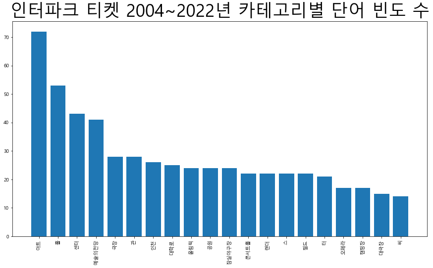

```python
# 단어 빈도 수가 많은 상위 20개 그래프 그리기
cc=[]
dd=[]
for i in tagss:
    for j in i:
        cc.append(j[0])
        dd.append(j[1])


cc=pd.Series(cc)
dd=pd.Series(dd)

df2=pd.concat([cc,dd],axis=1)
df2.columns=['단어','빈도수']
df2.to_csv('crawling_data2.csv',encoding='utf-8')

dfff=df2.iloc[:20]
plt.figure(figsize=(15,8))
plt.title('인터파크 티켓 2004~2022년 카테고리별 단어 빈도 수', fontsize=35)
plt.bar(dfff['단어'],dfff['빈도수'])
plt.xticks(rotation=90)
plt.show()
```

## 인터파크 티켓 현재 지역별 예매

```python
html=requests.get('http://ticket.interpark.com/TiKi/Special/TPRegionReserve.asp?Region=42001&RegionName=%BC%AD%BF%EF')
soup=BeautifulSoup(html.text, 'html.parser')
```

```python
# 지역 링크 뽑기
url=[]
div=soup.find('div',{'class':'Rg_list_tab'})
for i in div.find_all('a'):
    url.append(i['href'])

place_all=[]
for i in url:
    html1=requests.get('http://ticket.interpark.com'+i)
    soup1=BeautifulSoup(html1.text, 'html.parser')

    # 해당 지역 장소 리스트에 담기
    Gp=soup1.find_all('div',{'class':'Gp'})

    a=[]
    for i in Gp:
        a.append(i.find_all('div',{'class':'content'}))

    b=[]
    for i in a[4:]:
        for j in i:
            b.append(j.find('dd'))

    c=[]
    for i in b:
        c.append(i.find('p'))

    name=[]
    for i in c:
        name.append(i.find('a').text)

    e=[]
    for i in a[4:]:
        for j in i:
            e.append(j.find('dd',{'class':'place'}))

    place=[] #해당 지역 장소 담을 리스트
    for i in e:
        place.append(i.find('a').text)
    place_all.append(place)
```

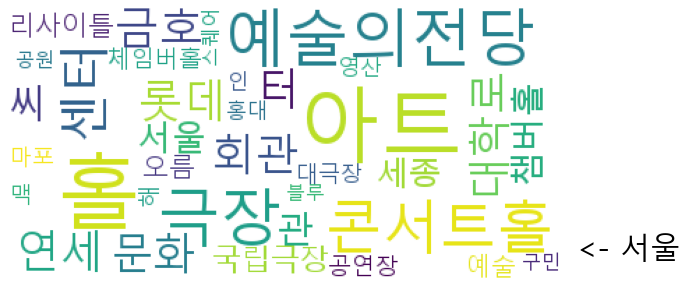

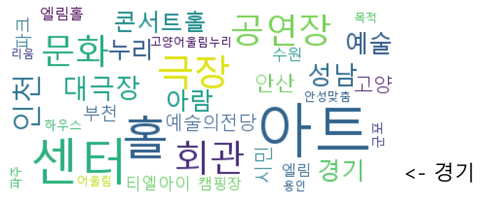

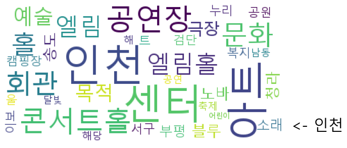

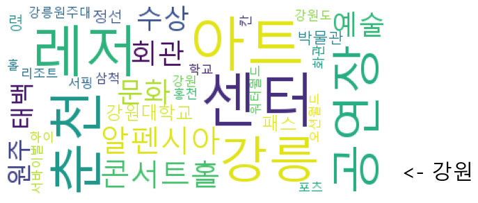

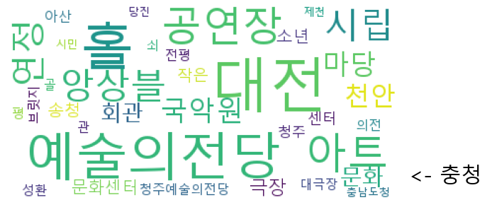

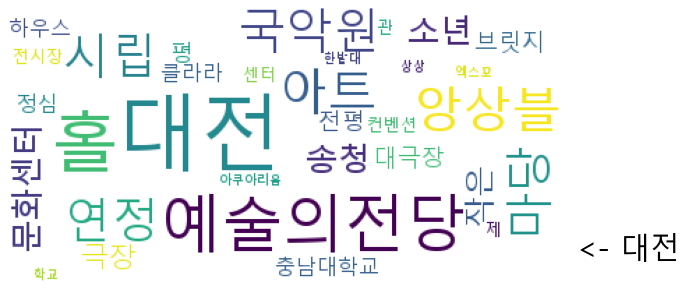

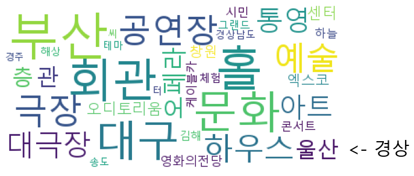

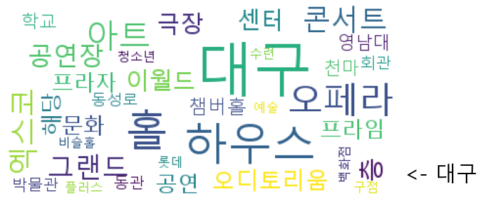

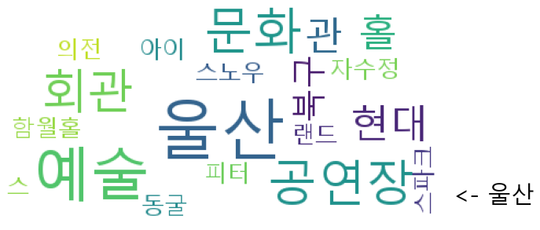

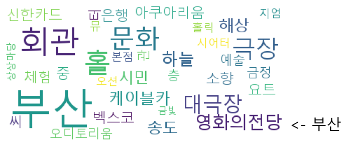

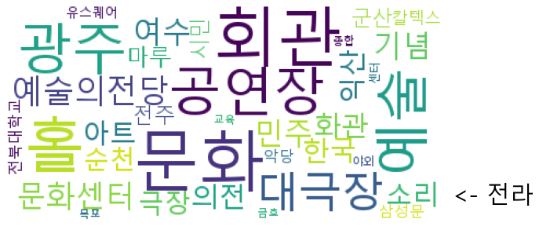

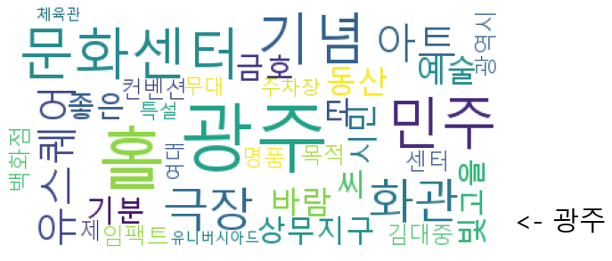

[1 more figures not shown]

```python
# 인터파크 티켓 현재 지역별 예매
tagg=[]
if platform.system() == 'Windows':
    font_name = fm.FontProperties(fname='../../EXAM_PANDAS/Fonts/malgun.ttf').get_name()
    plt.rc('font', family=font_name)

else:
    plt.rc('font', family='AppleGothic', size=8)


place_all[4].extend(place_all[5])
place_all[7].extend(place_all[8])
place_all[12].extend(place_all[13])

okt = Okt() # Open Korean Text 객체 생성

# okt함수를 통해 읽어들인 내용의 형태소를 분석한다.
sentences_tag1,sentences_tag2,sentences_tag3,sentences_tag4,sentences_tag5,sentences_tag6,sentences_tag7,sentences_tag8,sentences_tag9,sentences_tag10,sentences_tag11,sentences_tag12,sentences_tag13 = [],[],[],[],[],[],[],[],[],[],[],[],[]
sentences_tag1 = okt.pos(str(place_all[0]))
sentences_tag2 = okt.pos(str(place_all[1]))
sentences_tag3 = okt.pos(str(place_all[2]))
sentences_tag4 = okt.pos(str(place_all[3]))
sentences_tag5 = okt.pos(str(place_all[4]))
sentences_tag6 = okt.pos(str(place_all[6]))
sentences_tag7 = okt.pos(str(place_all[7]))
sentences_tag8 = okt.pos(str(place_all[9]))
sentences_tag9 = okt.pos(str(place_all[10]))
sentences_tag10 = okt.pos(str(place_all[11]))
sentences_tag11 = okt.pos(str(place_all[12]))
sentences_tag12 = okt.pos(str(place_all[14]))
sentences_tag13 = okt.pos(str(place_all[15]))

noun_adj_list = []
# tag가 명사이거나 형용사인 단어들만 noun_adj_list에 넣어준다.
# for i in range(1,14):
#     noun_adj_list=[]
for word, tag in sentences_tag1:
    if tag in ['Noun' , 'Adjective']:
        noun_adj_list.append(word)
#     noun_adj_list_all.append(noun_adj_list)

# print(noun_adj_list)
# 가장 많이 나온 단어부터 20개를 저장한다.
counts = Counter(noun_adj_list)
tags = counts.most_common(25)
# print(tags)
tagg.append(tags)
# WordCloud를 생성한다.
# 한글을 분석하기위해 font를 한글로 지정해주어야 된다. macOS는 .otf , window는 .ttf 파일의 위치를
# 지정해준다. (ex. '/Font/GodoM.otf')
if platform.system() == 'Windows':
    path = r'c:\Windows\Fonts\malgun.ttf'
elif platform.system() == 'Darwin': # Mac OS
    path = r'/System/Library/Fonts/AppleGothic'
else:
    path = r'/usr/share/fonts/truetype/name/NanumMyeongjo.ttf'

wc = WordCloud(font_path=path, background_color="white", max_font_size=60)
cloud = wc.generate_from_frequencies(dict(tags))

# 생성된 WordCloud를 test.jpg로 보낸다.
#cloud.to_file('test.jpg')
plt.figure(figsize=(10, 8))
plt.axis('off')
plt.imshow(cloud)
plt.text(x=400, y = 180 ,s=' <- 서울', color = 'black', fontsize = 30)
################################################################
noun_adj_list = []
for word, tag in sentences_tag2:
    if tag in ['Noun' , 'Adjective']:
        noun_adj_list.append(word)

counts = Counter(noun_adj_list)
tags = counts.most_common(25)
# print(tags)
tagg.append(tags)


wc = WordCloud(font_path=path, background_color="white", max_font_size=60)
cloud = wc.generate_from_frequencies(dict(tags))

plt.figure(figsize=(10, 8))
plt.axis('off')
plt.imshow(cloud)
plt.text(x=400, y = 180 ,s=' <- 경기', color = 'black', fontsize = 30)
###############################################################################
noun_adj_list = []
for word, tag in sentences_tag3:
    if tag in ['Noun' , 'Adjective']:
        noun_adj_list.append(word)

counts = Counter(noun_adj_list)
tags = counts.most_common(25)
# print(tags)
tagg.append(tags)


wc = WordCloud(font_path=path, background_color="white", max_font_size=60)
cloud = wc.generate_from_frequencies(dict(tags))

plt.figure(figsize=(10, 8))
plt.axis('off')
plt.imshow(cloud)
plt.text(x=400, y = 180 ,s=' <- 인천', color = 'black', fontsize = 30)
################################################################################
noun_adj_list = []
for word, tag in sentences_tag4:
    if tag in ['Noun' , 'Adjective']:
        noun_adj_list.append(word)

counts = Counter(noun_adj_list)
tags = counts.most_common(25)
# print(tags)
tagg.append(tags)


wc = WordCloud(font_path=path, background_color="white", max_font_size=60)
cloud = wc.generate_from_frequencies(dict(tags))

plt.figure(figsize=(10, 8))
plt.axis('off')
plt.imshow(cloud)
plt.text(x=400, y = 180 ,s=' <- 강원', color = 'black', fontsize = 30)
################################################################################
noun_adj_list = []
for word, tag in sentences_tag5:
    if tag in ['Noun' , 'Adjective']:
        noun_adj_list.append(word)

counts = Counter(noun_adj_list)
tags = counts.most_common(25)
# print(tags)
tagg.append(tags)


wc = WordCloud(font_path=path, background_color="white", max_font_size=60)
cloud = wc.generate_from_frequencies(dict(tags))

plt.figure(figsize=(10, 8))
plt.axis('off')
plt.imshow(cloud)
plt.text(x=400, y = 180 ,s=' <- 충청', color = 'black', fontsize = 30)
################################################################################

noun_adj_list = []
for word, tag in sentences_tag6:
    if tag in ['Noun' , 'Adjective']:
        noun_adj_list.append(word)

counts = Counter(noun_adj_list)
tags = counts.most_common(25)
# print(tags)
tagg.append(tags)


wc = WordCloud(font_path=path, background_color="white", max_font_size=60)
cloud = wc.generate_from_frequencies(dict(tags))

plt.figure(figsize=(10, 8))
plt.axis('off')
plt.imshow(cloud)
plt.text(x=400, y = 180 ,s=' <- 대전', color = 'black', fontsize = 30)
################################################################################

noun_adj_list = []
for word, tag in sentences_tag7:
    if tag in ['Noun' , 'Adjective']:
        noun_adj_list.append(word)

counts = Counter(noun_adj_list)
tags = counts.most_common(25)
# print(tags)
tagg.append(tags)


wc = WordCloud(font_path=path, background_color="white", max_font_size=60)
cloud = wc.generate_from_frequencies(dict(tags))

plt.figure(figsize=(10, 8))
plt.axis('off')
plt.imshow(cloud)
plt.text(x=400, y = 180 ,s=' <- 경상', color = 'black', fontsize = 30)
################################################################################
noun_adj_list = []
for word, tag in sentences_tag8:
    if tag in ['Noun' , 'Adjective']:
        noun_adj_list.append(word)

counts = Counter(noun_adj_list)
tags = counts.most_common(25)
# print(tags)
tagg.append(tags)


wc = WordCloud(font_path=path, background_color="white", max_font_size=60)
cloud = wc.generate_from_frequencies(dict(tags))

plt.figure(figsize=(10, 8))
plt.axis('off')
plt.imshow(cloud)
plt.text(x=400, y = 180 ,s=' <- 대구', color = 'black', fontsize = 30)
################################################################################
noun_adj_list = []
for word, tag in sentences_tag9:
    if tag in ['Noun' , 'Adjective']:
        noun_adj_list.append(word)

counts = Counter(noun_adj_list)
tags = counts.most_common(25)
# print(tags)
tagg.append(tags)


wc = WordCloud(font_path=path, background_color="white", max_font_size=60)
cloud = wc.generate_from_frequencies(dict(tags))

plt.figure(figsize=(10, 8))
plt.axis('off')
plt.imshow(cloud)
plt.text(x=400, y = 180 ,s=' <- 울산', color = 'black', fontsize = 30)
################################################################################
noun_adj_list = []
for word, tag in sentences_tag10:
    if tag in ['Noun' , 'Adjective']:
        noun_adj_list.append(word)

counts = Counter(noun_adj_list)
tags = counts.most_common(25)
# print(tags)
tagg.append(tags)


wc = WordCloud(font_path=path, background_color="white", max_font_size=60)
cloud = wc.generate_from_frequencies(dict(tags))

plt.figure(figsize=(10, 8))
plt.axis('off')
plt.imshow(cloud)
plt.text(x=400, y = 180 ,s=' <- 부산', color = 'black', fontsize = 30)
################################################################################
noun_adj_list = []
for word, tag in sentences_tag11:
    if tag in ['Noun' , 'Adjective']:
        noun_adj_list.append(word)

counts = Counter(noun_adj_list)
tags = counts.most_common(25)
# print(tags)
tagg.append(tags)


wc = WordCloud(font_path=path, background_color="white", max_font_size=60)
cloud = wc.generate_from_frequencies(dict(tags))

plt.figure(figsize=(10, 8))
plt.axis('off')
plt.imshow(cloud)
plt.text(x=400, y = 180 ,s=' <- 전라', color = 'black', fontsize = 30)
################################################################################
noun_adj_list = []
for word, tag in sentences_tag12:
    if tag in ['Noun' , 'Adjective']:
        noun_adj_list.append(word)

counts = Counter(noun_adj_list)
tags = counts.most_common(25)
# print(tags)
tagg.append(tags)


wc = WordCloud(font_path=path, background_color="white", max_font_size=60)
cloud = wc.generate_from_frequencies(dict(tags))

plt.figure(figsize=(10, 8))
plt.axis('off')
plt.imshow(cloud)
plt.text(x=400, y = 180 ,s=' <- 광주', color = 'black', fontsize = 30)
################################################################################
noun_adj_list = []
for word, tag in sentences_tag13:
    if tag in ['Noun' , 'Adjective']:
        noun_adj_list.append(word)

counts = Counter(noun_adj_list)
tags = counts.most_common(25)
# print(tags)
tagg.append(tags)

wc = WordCloud(font_path=path, background_color="white", max_font_size=60)
cloud = wc.generate_from_frequencies(dict(tags))

plt.figure(figsize=(10, 8))
plt.axis('off')
plt.imshow(cloud)
plt.text(x=400, y = 180 ,s=' <- 제주', color = 'black', fontsize = 30)
plt.show()
################################################################################
```